# Decoding Virality: A Comparative Analysis of Trending Videos on YouTube and TikTok

Pythoneers

Author

Varun Popli, Sophia Jukovich, Tatum Thomas, and Julia Schaffner

Published

December 4, 2023

Abstract

*This file contains the code for the project on Virality Across Social Media Platforms, as part of the STAT303-1 course in Fall 2023*.

## 1 Data quality check / cleaning / preparation

*By Varun*

```python
# Importing libraries
import pandas as pd
import numpy as np
import seaborn as sns
import matplotlib.pyplot as plt
import warnings
warnings.filterwarnings('ignore')
```

### 1.1 Distribution of variables

*By Julia and Tatum*

```python
# Creating a refined distribution summary table for YouTube data
refined_youtube_summary_data = []

for column in selected_youtube_variables:
    if youtube_data[column].dtype in ['int64', 'float64']:  # Continuous variables
        summary_stats = youtube_data[column].agg(['mean', 'median', 'min', 'max', 'std'])
        refined_youtube_summary_data.append({
            'Variable Name': column,
            'Type': 'Continuous',
            'Total Values': len(youtube_data[column]),
            'Missing Values': youtube_data[column].isnull().sum(),
            'Unique Values': youtube_data[column].nunique(),
            'Mean': summary_stats['mean'],
            'Median': summary_stats['median'],
            'Min': summary_stats['min'],
            'Max': summary_stats['max'],
            'Standard Deviation': summary_stats['std']
        })
    else:  # Categorical variables
        refined_youtube_summary_data.append({
            'Variable Name': column,
            'Type': 'Categorical',
            'Total Values': len(youtube_data[column]),
            'Missing Values': youtube_data[column].isnull().sum(),
            'Unique Values': youtube_data[column].nunique(),
            'Mean': None,
            'Median': None,
            'Min': None,
            'Max': None,
            'Standard Deviation': None
        })

refined_youtube_summary = pd.DataFrame(refined_youtube_summary_data)

# Selecting only the relevant variables for TikTok data
selected_tiktok_variables = ['n_likes', 'n_shares', 'n_comments', 'hashtags', 'n_plays']

# Creating a refined distribution summary table for TikTok data
refined_tiktok_summary_data = []

for column in selected_tiktok_variables:
    if tiktok_data[column].dtype in ['int64', 'float64']:  # Continuous variables
        summary_stats = tiktok_data[column].agg(['mean', 'median', 'min', 'max', 'std'])
        refined_tiktok_summary_data.append({
            'Variable Name': column,
            'Type': 'Continuous',
            'Total Values': len(tiktok_data[column]),
            'Missing Values': tiktok_data[column].isnull().sum(),
            'Unique Values': tiktok_data[column].nunique(),
            'Mean': summary_stats['mean'],
            'Median': summary_stats['median'],
            'Min': summary_stats['min'],
            'Max': summary_stats['max'],
            'Standard Deviation': summary_stats['std']
        })
    else:  # Categorical variables
        refined_tiktok_summary_data.append({
            'Variable Name': column,
            'Type': 'Categorical',
            'Total Values': len(tiktok_data[column]),
            'Missing Values': tiktok_data[column].isnull().sum(),
            'Unique Values': tiktok_data[column].nunique(),
            'Mean': None,
            'Median': None,
            'Min': None,
            'Max': None,
            'Standard Deviation': None
        })

refined_tiktok_summary = pd.DataFrame(refined_tiktok_summary_data)
```

```python
refined_youtube_summary
```

|  | Variable Name | Type | Total Values | Missing Values | Unique Values | Mean | Median | Min | Max | Standard Deviation |
| --- | --- | --- | --- | --- | --- | --- | --- | --- | --- | --- |
| 0 | likes | Continuous | 40379 | 0 | 29664 | 7.461677e+04 | 18371.0 | 0.0 | 5613827.0 | 2.296172e+05 |
| 1 | views | Continuous | 40379 | 0 | 39927 | 2.370839e+06 | 689597.0 | 549.0 | 225211923.0 | 7.428515e+06 |
| 2 | dislikes | Continuous | 40379 | 0 | 8460 | 3.508122e+03 | 637.0 | 0.0 | 1643059.0 | 2.317486e+04 |
| 3 | comment_count | Continuous | 40379 | 0 | 13684 | 8.287396e+03 | 1874.0 | 0.0 | 1228655.0 | 3.431605e+04 |
| 4 | publish_time | Categorical | 40379 | 0 | 6172 | NaN | NaN | NaN | NaN | NaN |
| 5 | trending_date | Categorical | 40379 | 0 | 205 | NaN | NaN | NaN | NaN | NaN |
| 6 | description | Categorical | 40379 | 0 | 6901 | NaN | NaN | NaN | NaN | NaN |

```python
refined_tiktok_summary
```

|  | Variable Name | Type | Total Values | Missing Values | Unique Values | Mean | Median | Min | Max | Standard Deviation |
| --- | --- | --- | --- | --- | --- | --- | --- | --- | --- | --- |
| 0 | n_likes | Continuous | 41675 | 0 | 12274 | 2.418634e+05 | 46100.0 | 0.0 | 22400000.0 | 6.853992e+05 |
| 1 | n_shares | Continuous | 41675 | 0 | 5544 | 2.223709e+03 | 146.0 | 0.0 | 727400.0 | 1.328490e+04 |
| 2 | n_comments | Continuous | 41675 | 0 | 6193 | 2.419286e+03 | 303.0 | 0.0 | 1200000.0 | 1.542691e+04 |
| 3 | hashtags | Categorical | 41675 | 0 | 17618 | NaN | NaN | NaN | NaN | NaN |
| 4 | n_plays | Continuous | 41675 | 0 | 11961 | 1.702802e+06 | 326900.0 | 0.0 | 508800000.0 | 6.437809e+06 |

### 1.2 Data cleaning

*By Sophia*

```python
# Reading the youtube data
youtube_data = pd.read_csv('USvideos.csv')
# Printing the missing values of youtube
print(youtube_data.isnull().sum())
# Dropping all the missing values
youtube_data = youtube_data.dropna()

# Reading the tiktok data
tiktok_data = pd.read_csv('sug_users_vids_all.csv')
# Printing the missing values of tiktok
print(tiktok_data.isnull().sum())
# Dropping all the missing values
tiktok_data = tiktok_data.dropna()
```

```
video_id                    0
trending_date               0
title                       0
channel_title               0
category_id                 0
publish_time                0
tags                        0
views                       0
likes                       0
dislikes                    0
comment_count               0
thumbnail_link              0
comments_disabled           0
ratings_disabled            0
video_error_or_removed      0
description               570
dtype: int64
id                0
create_time       0
user_name         0
hashtags          0
song             27
video_length      0
n_likes           0
n_shares          0
n_comments        0
n_plays           0
n_followers       0
n_total_likes     0
n_total_vids      0
dtype: int64
```

### 1.3 Data preparation

*By Sophia, Julia, Varun, and Tatum*

The following data preparation steps helped us to prepare our data for implementing various modeling:

1. Like-to-Ratio Column: In analysis 2, I studied like-to-comment ratios. In order to explore these ratios, I created new columns in both datasets in which the number of likes for each video was divided by the number of comments.
2. Time of Virality Column: In summary, this code loads YouTube data from a CSV file into a pandas DataFrame and then prints the contents of the DataFrame to the console. Then, it converts ‘trending_date’ to datetime format. The format is ‘YY.DD.MM’, so we need to rearrange it to ‘YY-MM-DD.’ for Analysis 3. Then I converted he ‘publish_time’ column to datetime format.’Publish_time’ includes time as well, so we will include it in the conversion. I then checked the first few rows to confirm the conversions. I then created a new column called ‘Time of Virality’ that is the difference in time between the trending date and publishing time. I then sorted the data from shortest to longest ‘Time of Virality’ values before extracting the numeric parts of the ‘Time of Virality’ column and conerting it to an integer. Lastly, I dropped all nonnumeric data points.
3. Data Aggregation: In analysis 2, I combined the datasets for a portion of the analysis by concatenating them.

```python
# Creating custom colors
# Importing libraries
from matplotlib.colors import ListedColormap
# Identifying custom colors
custom_colors = ['#fcdede','#f79d9d','#f25c5c','#a94040','#602424']
# Putting the colors to a value in order to implement in the code
custom_map = ListedColormap(custom_colors)
```

```python
# For analysis 1

# Goal: Create two dataset with the 100 most viewed videos in the youtube dataset and the tiktok dataset
# Make sure there are no repeats by dropping the duplicates in the data
youtube_data_unique = youtube_data.drop_duplicates(subset='video_id', keep='first')

# Create a new column 'views_rank' that ranks the videos by most views to least views
youtube_data_unique['views_rank'] = youtube_data_unique['views'].rank(ascending=False, method='max')

# Save the ranked and sorted data to a new data set
sorted_youtube_data = youtube_data_unique.sort_values(by='views_rank')

# Save the data once again but with only the top 100 observations
top_100_youtube = sorted_youtube_data.head(100)

# Repeat the same steps with the tiktok dataset however, ensure the variable names are changed to match those
    # in the tiktok dataset
# Make sure there are no repeats by dropping the duplicates in the data
tiktok_data_unique = tiktok_data.drop_duplicates(subset='id', keep='first')

# Create a new column 'n_plays_rank' that ranks the videos by most views to least views
tiktok_data_unique['n_plays_rank'] = tiktok_data_unique['n_plays'].rank(ascending=False, method='max')

# Save the ranked and sorted data to a new data set
sorted_tiktok_data = tiktok_data_unique.sort_values(by='n_plays_rank')

# Save the data once again but with only the top 100 observations
top_100_tiktok = sorted_tiktok_data.head(100)
```

```python
# For analysis 2:

tiktok_data['like_to_comment_ratio'] = tiktok_data['n_likes'] / tiktok_data['n_comments']
youtube_data['like_to_comment_ratio'] = youtube_data['likes'] / youtube_data['comment_count']

combined_data = pd.concat([
    tiktok_data[['like_to_comment_ratio', 'n_plays']].assign(platform='TikTok'),
    youtube_data[['like_to_comment_ratio', 'views']].assign(platform='YouTube'),
])
```

```python
# For analysis 3:

#In summary, this code loads YouTube data from a CSV file into a pandas DataFrame and then prints the contents of the DataFrame to the console.
youtube_data = pd.read_csv('USvideos.csv')
print(youtube_data)

# Converting 'trending_date' to datetime format
# The format is 'YY.DD.MM', so we need to rearrange it to 'YY-MM-DD'
youtube_data['trending_date'] = pd.to_datetime(youtube_data['trending_date'], format='%y.%d.%m')
youtube_data['trending_date'] = youtube_data['trending_date'].dt.date

# Converting 'publish_time' to datetime format
# 'publish_time' includes time as well, so we will include it in the conversion
youtube_data['publish_time'] = pd.to_datetime(youtube_data['publish_time'])
youtube_data['publish_time'] = youtube_data['publish_time'].dt.date

# Checking the first few rows to confirm the conversions
youtube_data[['trending_date', 'publish_time']].head()

#Creating new column called 'Time of Virality' that is the difference in time between the trending date and publishing time
youtube_data['Time_of_Virality'] = youtube_data['trending_date'] - youtube_data['publish_time']


# Cleaning the data
clean_youtube_data = youtube_data.dropna()
print(clean_youtube_data)

#Sorting the data from shortest to longest 'Time of Virality'
youtube_data_sorted = clean_youtube_data.sort_values(by=['Time_of_Virality'], ascending=True)
youtube_data_sorted['Time_of_Virality'] = youtube_data_sorted['Time_of_Virality'].astype(str)

# Extracting the numeric part and converting it to an integer
youtube_data_sorted['Time_of_Virality'] = youtube_data_sorted['Time_of_Virality'].str.extract('(\d+)').astype(int)

#Dropping all nonnumeric data
numeric_youtube_data = youtube_data_sorted.select_dtypes(include='number')
print(numeric_youtube_data)
```

```
          video_id trending_date  \
0      2kyS6SvSYSE      17.14.11
1      1ZAPwfrtAFY      17.14.11
2      5qpjK5DgCt4      17.14.11
3      puqaWrEC7tY      17.14.11
4      d380meD0W0M      17.14.11
...            ...           ...
40944  BZt0qjTWNhw      18.14.06
40945  1h7KV2sjUWY      18.14.06
40946  D6Oy4LfoqsU      18.14.06
40947  oV0zkMe1K8s      18.14.06
40948  ooyjaVdt-jA      18.14.06

                                                   title  \
0                     WE WANT TO TALK ABOUT OUR MARRIAGE
```

[output cut: 209 more lines]

#### 1.3.1 For analysis 4:

For my analysis, I added new columns indicating whether each video’s description contains a link and/or emojji. The code that creates these can be found in the code section of Analysis 4.

## 2 Exploratory data analysis

### 2.1 Analysis 1

*By Sophia Jukovich*

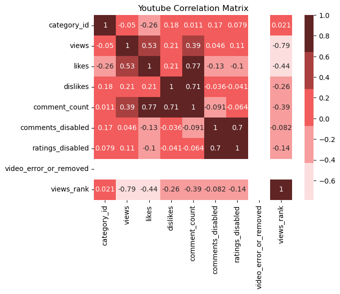

```python
# Goal: Explore the correlation between variables

# Create a correlation_matrix that correlates only the numeric variables
correlation_matrix = top_100_youtube.corr(numeric_only=True)
# Create a heatmap, using the corr matrix that was just made, showing the numeric corr names,
    # and using the custom color theme.
sns.heatmap(correlation_matrix, annot=True, cmap=custom)
# Title the graph
plt.title('Youtube Correlation Matrix')
# Show the figure
plt.show()

# Focus on views, likes, dislikes, comment_count
```

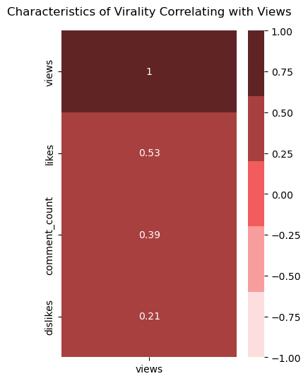

```python
# Goal: Create a singular heatmap with specific variables that all correlate positivly with 'views'

# Setting the size of the figure
plt.figure(figsize=(4, 6))
# Creating a list of variables to correlate with 'views'
variables_to_correlate = ['views', 'likes', 'dislikes', 'comment_count']
# Creating a correlation martix
correlation_matrix = top_100_youtube[variables_to_correlate].corr()
# Creating a heatmap that correlates with the variable 'views', specifying different aspects of the graph
heatmap = sns.heatmap(correlation_matrix[['views']].sort_values(by='views', ascending=False), vmin=-1, vmax=1, annot=True, cmap=custom)
# Adding a title, specifying font and location
heatmap.set_title('Characteristics of Virality Correlating with Views', fontdict={'fontsize':12}, pad=16)
```

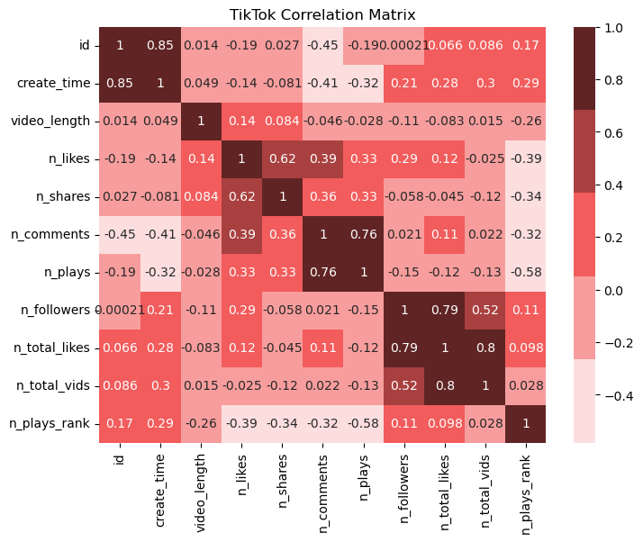

```python
# Goal: Create a heatmap with all numeric variables in the tiktok dataset

# Creating a correlation matrix based on only the numeric variables
correlation_matrix = top_100_tiktok.corr(numeric_only=True)
# Setting the size of the figure
plt.figure(figsize=(8, 6))
# Making the heatmap with the correlation matrix, specifying corr numeric values to be shown on the graph and color
sns.heatmap(correlation_matrix, annot=True, cmap=custom)
# Setting a title
plt.title('TikTok Correlation Matrix')
# Showing the graph
plt.show()

# n_likes, n_plays, n_comments, n_shares
    # could also do something about n_total_likes and n_total_vids
```

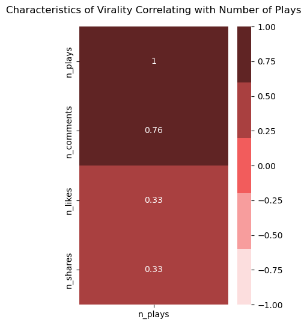

```python
# Goal: Create a singular heatmap with different positively correlated variables with 'n_plays'

# Setting the figure size
plt.figure(figsize=(4, 6))
# Creating a list of positively correlated variables
variables_to_correlate = ['n_likes', 'n_comments', 'n_plays', 'n_shares']
# Creating a correlation matrix out of the variables_to_correlate list
correlation_matrix = top_100_tiktok[variables_to_correlate].corr()
# Create a heatmap that shows the correlation of different variables based on 'n_plays', specifying different aspects of the graph
heatmap = sns.heatmap(correlation_matrix[['n_plays']].sort_values(by='n_plays', ascending=False), vmin=-1, vmax=1, annot=True, cmap=custom)
# Setting the title of the graph, font size, and position
heatmap.set_title('Characteristics of Virality Correlating with Number of Plays', fontdict={'fontsize':12}, pad=16)
```

```
Stats for YouTube trendline: LinregressResult(slope=0.037416836330092094, intercept=140881.47099484655, rvalue=0.5278281125603275, pvalue=1.6698372480972645e-08, stderr=0.006082033676638221, intercept_stderr=87729.77955862979)
Stats for TikTok trendline: LinregressResult(slope=0.019148594444891174, intercept=6189250.2756414255, rvalue=0.33377310637190166, pvalue=0.0006897136985038616, stderr=0.005462916730286116, intercept_stderr=594980.4536751393)
```

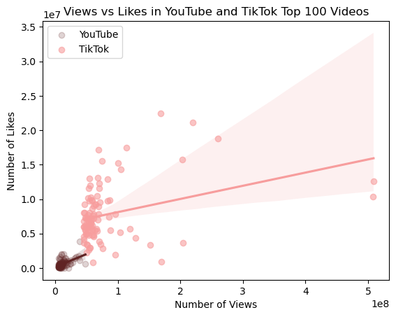

```python
# Goal: Create a scatter plot of views v.s. likes with a trendline and slope calculations

# Importing the SciPy library (numeric computing library) specifically stats submodule
    # Getting linregress function for a linear regression analysis (I am only using it for slope in this case)
from scipy.stats import linregress

# Extract x and y values for each dataset
x1 = top_100_youtube['views']
y1 = top_100_youtube['likes']

x2 = top_100_tiktok['n_plays']
y2 = top_100_tiktok['n_likes']

# Creating a line for each dataset on the same plot
    # Used different alpha values because youtube data was more clustered
sns.regplot(x=x1, y=y1, label='YouTube', color='#602424', scatter_kws={'alpha':0.2})
sns.regplot(x=x2, y=y2, label='TikTok', color='#f79d9d', scatter_kws={'alpha':0.6})

# Set labels and title
plt.xlabel('Number of Views')
plt.ylabel('Number of Likes')
plt.title('Views vs Likes in YouTube and TikTok Top 100 Videos')

# Calculate the trendline slopes
slope_youtube= linregress(x1, y1)
slope_tiktok= linregress(x2, y2)

# Print out the stats for youtube and tiktok
    # I only used the slope result
print('Stats for YouTube trendline:', slope_youtube)
print('Stats for TikTok trendline:', slope_tiktok)

# Create a legend and specify the placement
plt.legend(loc='upper left')

# Show the plot
plt.show()
```

```
Slope of YouTube trendline: LinregressResult(slope=0.006229967953860186, intercept=10431.690209289402, rvalue=0.392089071404878, pvalue=5.4747092704190905e-05, stderr=0.001476527448426562, intercept_stderr=21298.0451029544)
Slope of TikTok trendline: LinregressResult(slope=0.0019970685034583443, intercept=-61101.2124004193, rvalue=0.7576164838277897, pvalue=7.320411827564599e-20, stderr=0.0001737977334391121, intercept_stderr=18928.76267288409)
```

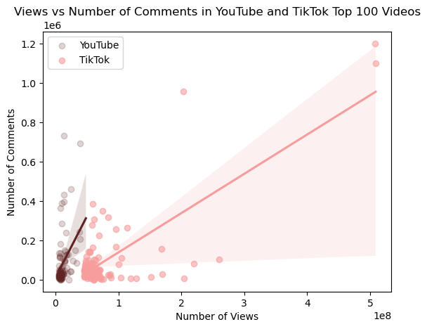

```python
# Goal: Create a scatter plot of views v.s. comments with a trendline and slope calculations
    # Essentially same steps as last plot however with a different y-axis variable

# Importing the SciPy library (numeric computing library) specifically stats submodule
    # Getting linregress function for a linear regression analysis (I am only using it for slope in this case)
from scipy.stats import linregress

# Extract x and y values for each dataset
x1 = top_100_youtube['views']
y1 = top_100_youtube['comment_count']

x2 = top_100_tiktok['n_plays']
y2 = top_100_tiktok['n_comments']

# Creating a line for each dataset on the same plot
    # Used different alpha values because youtube data was more clustered
sns.regplot(x=x1, y=y1, label='YouTube', color='#602424', scatter_kws={'alpha':0.2})
sns.regplot(x=x2, y=y2, label='TikTok', color='#f79d9d', scatter_kws={'alpha':0.6})

# Set labels and title
plt.xlabel('Number of Views')
plt.ylabel('Number of Comments')
plt.title('Views vs Number of Comments in YouTube and TikTok Top 100 Videos')

# Calculate the trendline slopes
slope_youtube= linregress(x1, y1)
slope_tiktok= linregress(x2, y2)

# Print out the stats for youtube and tiktok
    # I only used the slope result
print('Slope of YouTube trendline:', slope_youtube)
print('Slope of TikTok trendline:',slope_tiktok)

# Create a legend and specify the placement
plt.legend()

# Show the plot
plt.show()
```

### 2.2 Analysis 2

*By Julia Schaffner*

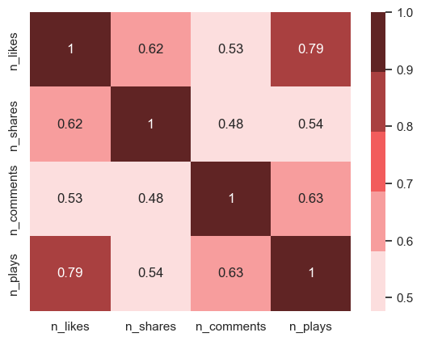

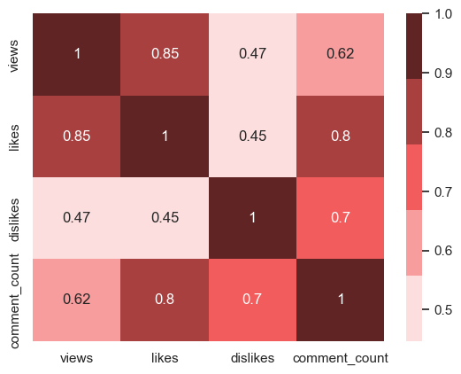

```python
# For TikTok data:
# Selecting only columns with interaction metrics:
tiktok_data_interaction_metrics = tiktok_data.iloc[:, 6:10]

# Generate a heatmap for the correlation matrix of TikTok interaction metrics
sns.heatmap(tiktok_data_interaction_metrics.corr(), annot=True, cmap=custom_map)
plt.show()

# For YouTube Data:
# Selecting only columns with interaction metrics:
youtube_data_interaction_metrics = youtube_data.iloc[:, [7, 8, 9, 10]]

# Generate a heatmap for the correlation matrix of YouTube interaction metrics.
sns.heatmap(youtube_data_interaction_metrics.corr(), annot=True, cmap=custom_map)
plt.show()
```

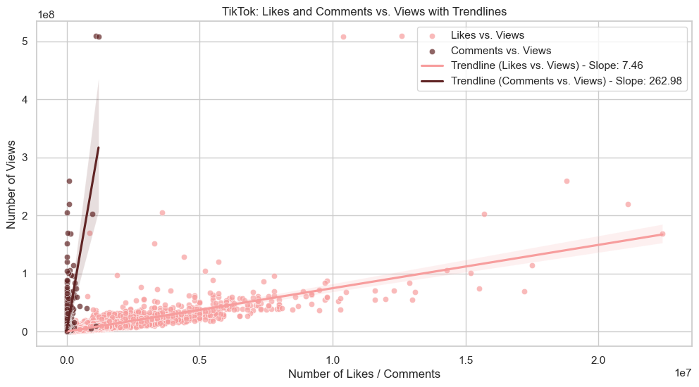

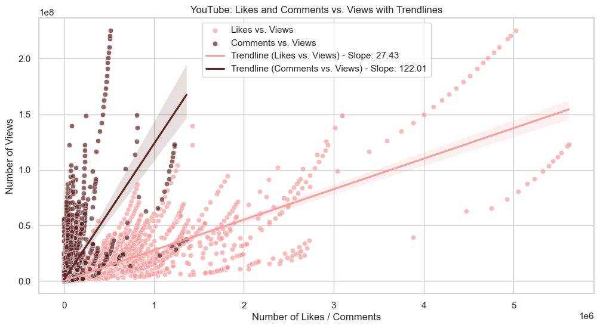

```python
from scipy.stats import linregress

# For Tiktok:

# Create a scatter plot with trendlines for Likes vs. Views and Comments vs. Views
plt.figure(figsize=(12, 6))

# Scatter plot for Likes vs. Views
sns.scatterplot(x='n_likes', y='n_plays', data=tiktok_data, label='Likes vs. Views', alpha=0.7, color='#f79d9d')

# Scatter plot for Comments vs. Views
sns.scatterplot(x='n_comments', y='n_plays', data=tiktok_data, label='Comments vs. Views', alpha=0.7, color='#602424')

# Add trendlines to both graphs
slope_likes, intercept_likes, _, _, _ = linregress(tiktok_data['n_likes'], tiktok_data['n_plays'])
slope_comments, intercept_comments, _, _, _ = linregress(tiktok_data['n_comments'], tiktok_data['n_plays'])

sns.regplot(x='n_likes', y='n_plays', data=tiktok_data, scatter=False, label=f'Trendline (Likes vs. Views) - Slope: {slope_likes:.2f}', color='#f79d9d')
sns.regplot(x='n_comments', y='n_plays', data=tiktok_data, scatter=False, label=f'Trendline (Comments vs. Views) - Slope: {slope_comments:.2f}', color='#602424')

# Set labels and title
plt.xlabel('Number of Likes / Comments')
plt.ylabel('Number of Views')
plt.title('TikTok: Likes and Comments vs. Views with Trendlines')

# Show legend
plt.legend()

# Show the plot
plt.show()

# For YouTube:

plt.figure(figsize=(12, 6))

# Scatter plot for Likes vs. Views
sns.scatterplot(x='likes', y='views', data=youtube_data, label='Likes vs. Views', alpha=0.7, color='#f79d9d')

# Scatter plot for Comments vs. Views
sns.scatterplot(x='comment_count', y='views', data=youtube_data, label='Comments vs. Views', alpha=0.7, color='#602424')

# Add trendlines
slope_likes, intercept_likes, _, _, _ = linregress(youtube_data['likes'], youtube_data['views'])
slope_comments, intercept_comments, _, _, _ = linregress(youtube_data['comment_count'], youtube_data['views'])

sns.regplot(x='likes', y='views', data=youtube_data, scatter=False, label=f'Trendline (Likes vs. Views) - Slope: {slope_likes:.2f}', color='#f79d9d')
sns.regplot(x='comment_count', y='views', data=youtube_data, scatter=False, label=f'Trendline (Comments vs. Views) - Slope: {slope_comments:.2f}', color='#602424')

# Set labels and title
plt.xlabel('Number of Likes / Comments')
plt.ylabel('Number of Views')
plt.title('YouTube: Likes and Comments vs. Views with Trendlines')

# Show legend
plt.legend()

# Show the plot
plt.show()
```

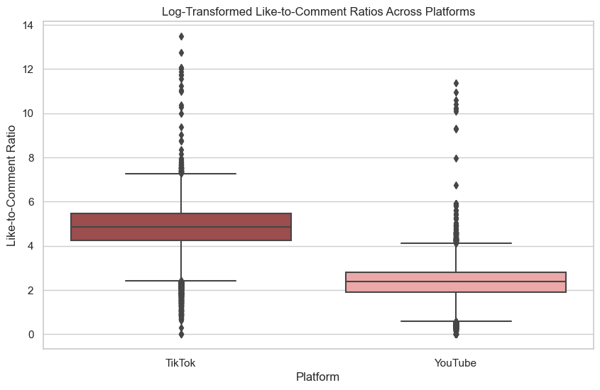

```python
# Associate one color with each platform using a dictionary
platform_colors = {'TikTok': '#a94040', 'YouTube': '#f79d9d'}

plt.figure(figsize=(10, 6))

# perform a logarithmic transformation on the like-to-comment ratio column to alleviate skweness

combined_data['log_like_to_comment_ratio'] = np.log1p(combined_data['like_to_comment_ratio'])

# Create a boxplot to visualize distribution like-to-comment ratios on both platforms
sns.boxplot(x='platform', y='log_like_to_comment_ratio', data=combined_data, palette = platform_colors)
plt.title('Log-Transformed Like-to-Comment Ratios Across Platforms')
plt.xlabel('Platform')
plt.ylabel('Like-to-Comment Ratio')
plt.show()
```

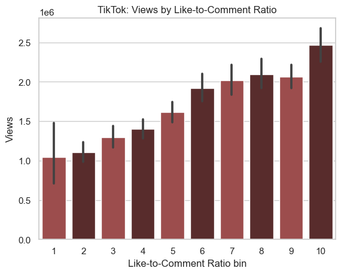

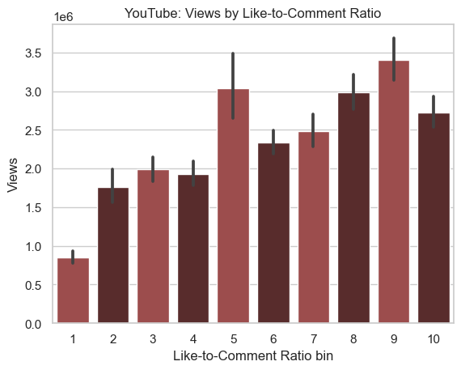

```python
# For TikTok:

# Bin the like-to-comment ratio column on TikTok

binned_ratio_tt = pd.qcut(tiktok_data['like_to_comment_ratio'],10, labels = ['1','2','3', '4', '5', '6', '7', '8', '9', '10'], retbins=True)

binned_ratio_tt[0] # The first output is the cat col that we created by binning
binned_ratio_tt[1] # The second output is the bin limits

# Create a new column for the ratio bins
tiktok_data['ratio_bin'] = binned_ratio_tt[0]


# Create a barplot with averages and Confidence intervals using the bins

sns.barplot(x = 'ratio_bin', y = 'n_plays', data = tiktok_data, palette = custom_colors)
plt.xlabel('Like-to-Comment Ratio bin')
plt.ylabel('Views')
plt.title('TikTok: Views by Like-to-Comment Ratio')

plt.show()

# For YouTube:

# Bin the like-to-comment ratio column on YouTube

binned_ratio_yt = pd.qcut(youtube_data['like_to_comment_ratio'],10, labels = ['1','2','3', '4', '5', '6', '7', '8', '9', '10'], retbins=True)

binned_ratio_yt[0] # The first output is the cat col that we created by binning
binned_ratio_yt[1] # The second output is the bin limits

# Creating new column for the ratio bins
youtube_data['ratio_bin'] = binned_ratio_yt[0]

# Create a barplot with averages and Confidence intervals using the bins

sns.barplot(x = 'ratio_bin', y = 'views', data = youtube_data, palette = custom_colors)
plt.xlabel('Like-to-Comment Ratio bin')
plt.ylabel('Views')
plt.title('YouTube: Views by Like-to-Comment Ratio')

plt.show()
```

### 2.3 Analysis 3

*By Varun Popli*

```
                  category_id     views     likes  dislikes  comment_count  \
category_id          1.000000 -0.168860 -0.174073 -0.047387      -0.086625
views               -0.168860  1.000000  0.848746  0.558108       0.655819
likes               -0.174073  0.848746  1.000000  0.514691       0.853380
dislikes            -0.047387  0.558108  0.514691  1.000000       0.623131
comment_count       -0.086625  0.655819  0.853380  0.623131       1.000000
Time_of_Virality    -0.032879 -0.012524 -0.015858 -0.007225      -0.012767

                  Time_of_Virality
category_id              -0.032879
views                    -0.012524
likes                    -0.015858
dislikes                 -0.007225
comment_count            -0.012767
Time_of_Virality          1.000000
```

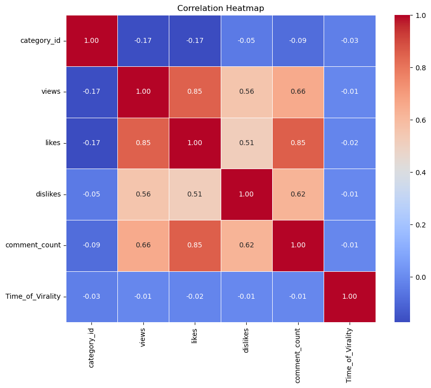

```python
#Calculate and print the correlation values between the numeric variables
correlation_matrix = numeric_youtube_data.corr()
print(correlation_matrix)

#Create a heatmap that tracks the correlation values between the numeric values
plt.figure(figsize=(10, 8))
sns.heatmap(correlation_matrix, annot=True, cmap='coolwarm', fmt=".2f", linewidths=0.5)
plt.title("Correlation Heatmap")
plt.show()
```

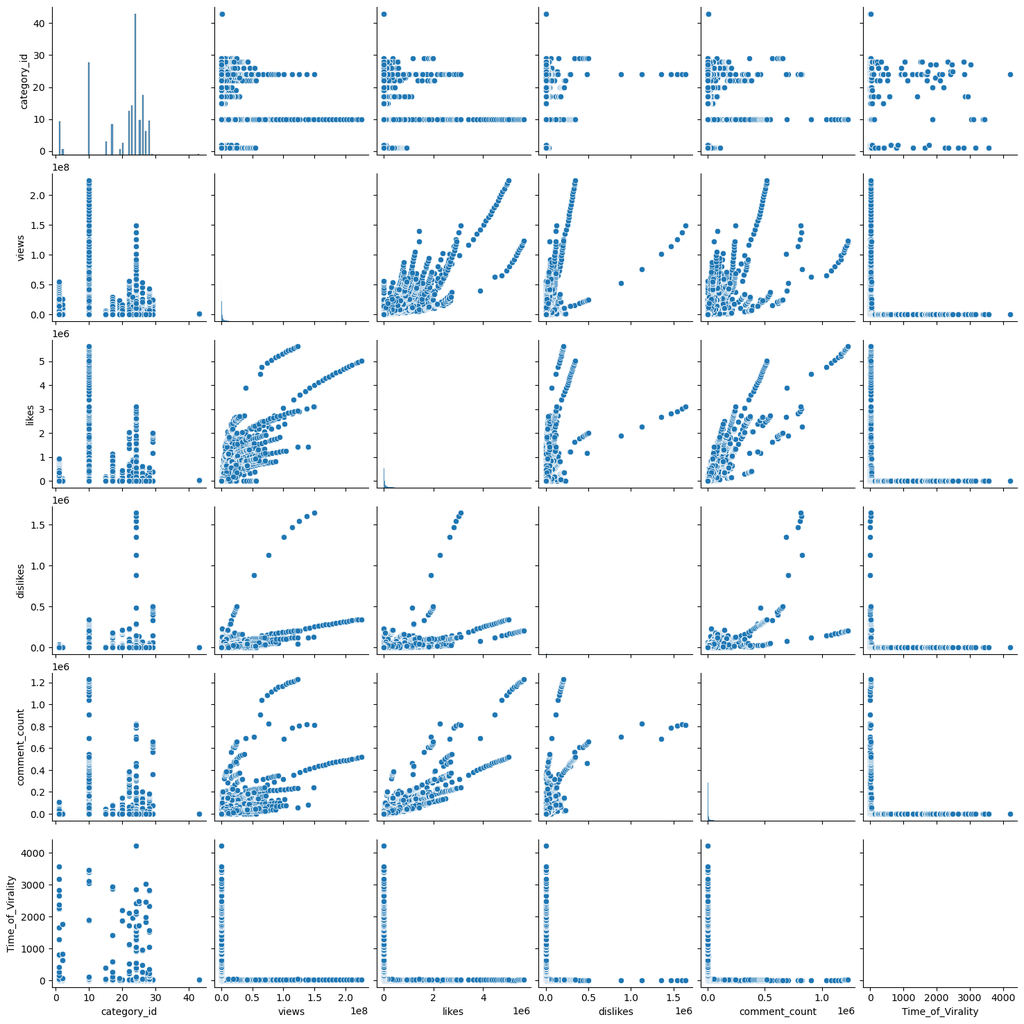

```python
# Create a pair plot that is a collection of scatterplots that track the relationship between the numeric variables]\
sns.pairplot(numeric_youtube_data)
plt.show()
```

### 2.4 Analysis 4

*By Tatum Thomas*

This code calculates the length of each video description in a YouTube dataset and creates scatter plots with regression lines to analyze the relationships between the length of video descriptions and three metrics: likes, dislikes, and comment count. It displays these relationships graphically and denotes each plot with the correlation coefficient between description length and each metric.

```
-0.01434077930237259
```

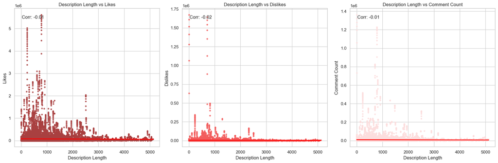

```python
# Calculating the length of each video description
youtube_data['description_length'] = youtube_data['description'].str.len().fillna(0)

# Calculate the length of each video description
youtube_data['description_length'] = youtube_data['description'].astype(str).apply(len)

# Calculate the correlation between description length and views
correlation = youtube_data['description_length'].corr(youtube_data['views'])
print(correlation)

# Setting up the figure for scatter plots with regression lines
fig, axes = plt.subplots(1, 3, figsize=(18, 6))
colors = ["#a94040", "#602424"]
# Description Length vs Likes
sns.regplot(ax=axes[0], data=youtube_data, x='description_length', y='likes', scatter_kws={'s':10, 'color': '#a94040'}, line_kws={'color':'red'})
axes[0].set_title('Description Length vs Likes')
axes[0].set_xlabel('Description Length')
axes[0].set_ylabel('Likes')
corr_likes = np.corrcoef(youtube_data['description_length'], youtube_data['likes'])[0, 1]
axes[0].annotate(f'Corr: {corr_likes:.2f}', xy=(0.05, 0.95), xycoords='axes fraction', fontsize=12, ha='left', va='top')

# Description Length vs Dislikes
sns.regplot(ax=axes[1], data=youtube_data, x='description_length', y='dislikes', scatter_kws={'s':10, 'color': '#f25c5c'}, line_kws={'color':'red'})
axes[1].set_title('Description Length vs Dislikes')
axes[1].set_xlabel('Description Length')
axes[1].set_ylabel('Dislikes')
corr_dislikes = np.corrcoef(youtube_data['description_length'], youtube_data['dislikes'])[0, 1]
axes[1].annotate(f'Corr: {corr_dislikes:.2f}', xy=(0.05, 0.95), xycoords='axes fraction', fontsize=12, ha='left', va='top')

# Description Length vs Comment Count
sns.regplot(ax=axes[2], data=youtube_data, x='description_length', y='comment_count', scatter_kws={'s':10, 'color': '#fcdede'}, line_kws={'color':'red'})
axes[2].set_title('Description Length vs Comment Count')
axes[2].set_xlabel('Description Length')
axes[2].set_ylabel('Comment Count')
corr_comments = np.corrcoef(youtube_data['description_length'], youtube_data['comment_count'])[0, 1]
axes[2].annotate(f'Corr: {corr_comments:.2f}', xy=(0.05, 0.95), xycoords='axes fraction', fontsize=12, ha='left', va='top')

plt.tight_layout()
plt.show()
```

This code analyzes and visualizes the impact of using emojis in YouTube video descriptions on viewer engagement metrics such as views, likes, dislikes, and comment count. It groups the data based on whether the descriptions contain emojis or not, calculates the average of these metrics for each group, and then creates a series of bar plots to compare these averages. The goal is to determine if the presence of emojis in descriptions correlates with differences in viewer engagement.

```
Count of videos with and without emojis:
contains_emoji
False    31598
True      9351
Name: count, dtype: int64
```

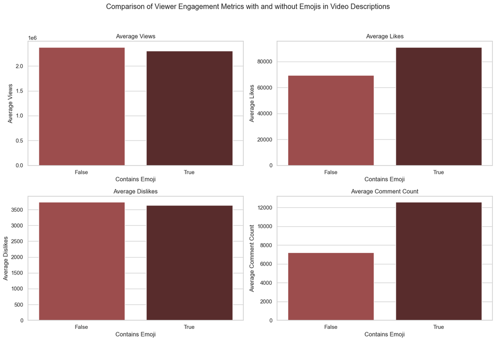

| contains_emoji | views | likes | dislikes | comment_count |
| --- | --- | --- | --- | --- |
| False | 2.377564e+06 | 69322.426673 | 3733.829515 | 7224.526869 |
| True | 2.304084e+06 | 90973.923645 | 3635.612234 | 12577.003957 |

```python
import re

# Check if a given string (s) contains any emojis
def contains_emoji(s):
    """
    Check if the string contains an emoji.
    """
    emoji_pattern = re.compile("["
                           u"\U0001F600-\U0001F64F"  # emoticons
                           u"\U0001F300-\U0001F5FF"  # symbols & pictographs
                           u"\U0001F680-\U0001F6FF"  # transport & map symbols
                           u"\U0001F1E0-\U0001F1FF"  # flags (iOS)
                           u"\U00002702-\U000027B0"
                           u"\U000024C2-\U0001F251"
                           "]+", flags=re.UNICODE)
    return bool(emoji_pattern.search(s))

# Apply the functions to the description column
youtube_data['contains_emoji'] = youtube_data['description'].apply(lambda x: contains_emoji(str(x)))


# Grouping by 'contains_emoji' and calculating mean values for engagement metrics
grouped_data_emoji = youtube_data.groupby('contains_emoji')[['views', 'likes', 'dislikes', 'comment_count']].mean()

# Determining how many videos have emojis
youtube_data['contains_emoji'] = youtube_data['description'].apply(lambda x: contains_emoji(str(x)))
emoji_count = youtube_data['contains_emoji'].value_counts()
print("Count of videos with and without emojis:")
print(emoji_count)

sns.set(style="whitegrid")

fig, axes = plt.subplots(2, 2, figsize=(14, 10))
fig.suptitle('Comparison of Viewer Engagement Metrics with and without Emojis in Video Descriptions')
colors = ["#a94040", "#602424"]

sns.barplot(ax=axes[0, 0], x=grouped_data_emoji.index, y=grouped_data_emoji['views'], palette=colors)
axes[0, 0].set_title('Average Views')
axes[0, 0].set_xlabel('Contains Emoji')
axes[0, 0].set_ylabel('Average Views')

sns.barplot(ax=axes[0, 1], x=grouped_data_emoji.index, y=grouped_data_emoji['likes'],palette=colors)
axes[0, 1].set_title('Average Likes')
axes[0, 1].set_xlabel('Contains Emoji')
axes[0, 1].set_ylabel('Average Likes')

sns.barplot(ax=axes[1, 0], x=grouped_data_emoji.index, y=grouped_data_emoji['dislikes'],palette=colors)
axes[1, 0].set_title('Average Dislikes')
axes[1, 0].set_xlabel('Contains Emoji')
axes[1, 0].set_ylabel('Average Dislikes')

sns.barplot(ax=axes[1, 1], x=grouped_data_emoji.index, y=grouped_data_emoji['comment_count'],palette=colors)
axes[1, 1].set_title('Average Comment Count')
axes[1, 1].set_xlabel('Contains Emoji')
axes[1, 1].set_ylabel('Average Comment Count')

plt.tight_layout(rect=[0, 0.03, 1, 0.95])
plt.show()

grouped_data_emoji = youtube_data.groupby('contains_emoji')[['views', 'likes', 'dislikes', 'comment_count']].mean()
grouped_data_emoji
```

This code examines the relationship between the presence of links in YouTube video descriptions and viewer engagement metrics (views, likes, dislikes, comment count). It first identifies videos with links in their descriptions, then groups the data based on this criterion and calculates the mean engagement metrics for each group. The results are visualized using bar plots to compare the average engagement metrics for videos with and without links in their descriptions. The goal is to understand if including links in video descriptions influences viewer engagement.

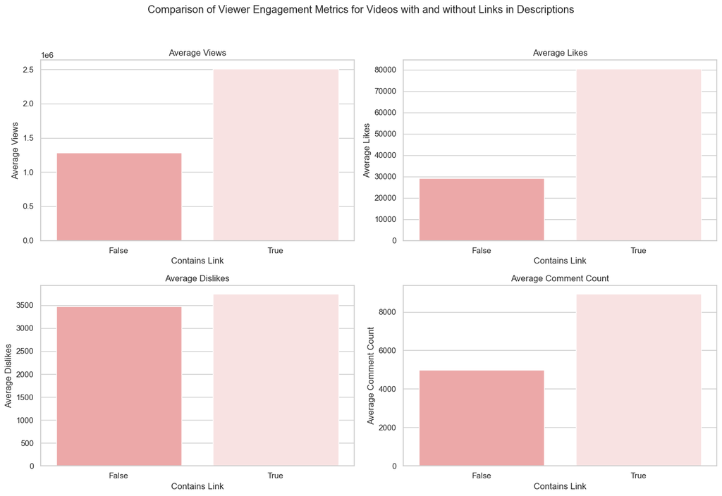

| contains_link | views | likes | dislikes | comment_count |
| --- | --- | --- | --- | --- |
| False | 1.282002e+06 | 29215.920379 | 3472.328764 | 4984.365249 |
| True | 2.509496e+06 | 80477.020590 | 3744.357341 | 8924.106035 |

```python
# Check if a given string (s) contains a hyperlink
def contains_link(s):
    return 'http://' in str(s) or 'https://' in str(s) or 'www.' in str(s)
youtube_data['contains_link'] = youtube_data['description'].apply(contains_link)

# Group by 'contains_link' and calculate mean values for engagement metrics
grouped_data_link = youtube_data.groupby('contains_link')[['views', 'likes', 'dislikes', 'comment_count']].mean()

sns.set(style="whitegrid")

fig, axes = plt.subplots(2, 2, figsize=(14, 10))
fig.suptitle('Comparison of Viewer Engagement Metrics for Videos with and without Links in Descriptions')

colors = ["#f79d9d", "#fcdede"]

sns.barplot(ax=axes[0, 0], x=grouped_data_link.index, y=grouped_data_link['views'], palette=colors)
axes[0, 0].set_title('Average Views')
axes[0, 0].set_xlabel('Contains Link')
axes[0, 0].set_ylabel('Average Views')


sns.barplot(ax=axes[0, 1], x=grouped_data_link.index, y=grouped_data_link['likes'], palette=colors)
axes[0, 1].set_title('Average Likes')
axes[0, 1].set_xlabel('Contains Link')
axes[0, 1].set_ylabel('Average Likes')


sns.barplot(ax=axes[1, 0], x=grouped_data_link.index, y=grouped_data_link['dislikes'], palette=colors)
axes[1, 0].set_title('Average Dislikes')
axes[1, 0].set_xlabel('Contains Link')
axes[1, 0].set_ylabel('Average Dislikes')


sns.barplot(ax=axes[1, 1], x=grouped_data_link.index, y=grouped_data_link['comment_count'], palette=colors)
axes[1, 1].set_title('Average Comment Count')
axes[1, 1].set_xlabel('Contains Link')
axes[1, 1].set_ylabel('Average Comment Count')

plt.tight_layout(rect=[0, 0.03, 1, 0.95])
plt.show()
grouped_data_link = youtube_data.groupby('contains_link')[['views', 'likes', 'dislikes', 'comment_count']].mean()

grouped_data_link
```

This code processes TikTok data to analyze the relationship between the number of hashtags used in a video and the average number of likes and comments it receives. It converts the string representation of hashtags into actual lists, bins these lists based on the count of hashtags, and then groups the data by these bins to calculate the average likes and comments for each bin. The results are visualized using bar plots, providing insights into how hashtag usage correlates with viewer engagement on TikTok.

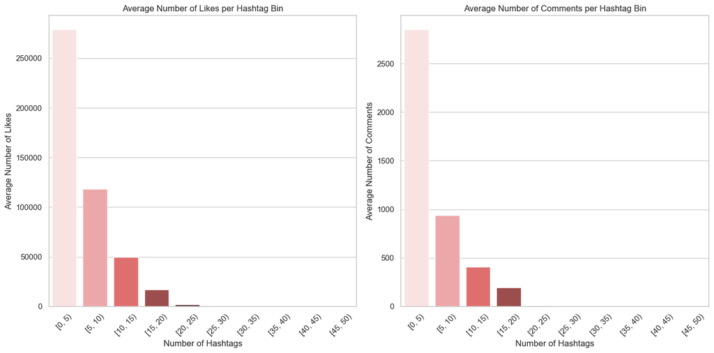

```python
# Convert hashtags from string representation of a list to actual list and count them
tiktok_data['hashtag_count'] = tiktok_data['hashtags'].apply(lambda x: len(eval(x)) if pd.notnull(x) else 0)

# Define the bins for the number of hashtags
bins = [0, 5, 10, 15, 20, 25, 30, 35, 40, 45, 50]

# Create a new column 'hashtag_bin' to indicate the bin each video falls into
tiktok_data['hashtag_bin'] = pd.cut(tiktok_data['hashtag_count'], bins=bins, include_lowest=True, right=False)

# Aggregate the data by these bins and calculate the mean of likes and comments
aggregated_data = tiktok_data.groupby('hashtag_bin')[['n_likes', 'n_comments']].mean().reset_index()


# Now, let's create bar plots for each aggregated measure
fig, ax = plt.subplots(1, 2, figsize=(14, 7))
custom_colors = ["#fcdede", "#f79d9d", "#f25c5c", "#a94040", "#602424"]
# Bar plot for average likes per hashtag bin
sns.barplot(ax=ax[0], x='hashtag_bin', y='n_likes', data=aggregated_data, palette=custom_colors)
ax[0].set_title('Average Number of Likes per Hashtag Bin')
ax[0].set_xlabel('Number of Hashtags')
ax[0].set_ylabel('Average Number of Likes')
ax[0].tick_params(axis='x', rotation=45)  # Rotate x-axis labels for readability

# Bar plot for average comments per hashtag bin
sns.barplot(ax=ax[1], x='hashtag_bin', y='n_comments', data=aggregated_data, palette=custom_colors)
ax[1].set_title('Average Number of Comments per Hashtag Bin')
ax[1].set_xlabel('Number of Hashtags')
ax[1].set_ylabel('Average Number of Comments')
ax[1].tick_params(axis='x', rotation=45)  # Rotate x-axis labels for readability

plt.tight_layout()
plt.show()
```

This code analyzes TikTok data to determine how the presence of emojis in video hashtags affects the number of likes the videos receive. It defines a regular expression to identify emojis and applies it to the hashtags in the dataset, creating a new column indicating whether each video’s hashtags contain emojis. The data is then grouped by this emoji presence, and the average number of likes for each group is calculated and visualized using a box plot. This visualization helps in understanding the impact of using emojis in hashtags on user engagement on TikTok.

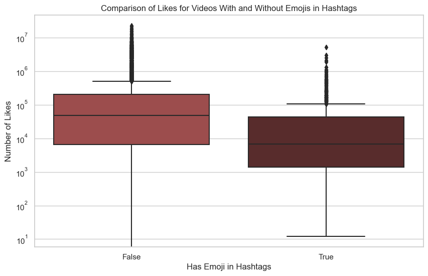

```python
# Regex pattern for detecting emojis
emoji_pattern = re.compile(
    "["
    "\U0001F600-\U0001F64F"  # emoticons
    "\U0001F300-\U0001F5FF"  # symbols & pictographs
    "\U0001F680-\U0001F6FF"  # transport & map symbols
    "\U0001F1E0-\U0001F1FF"  # flags (iOS)
    "\U00002702-\U000027B0"
    "\U000024C2-\U0001F251"
    "]+", flags=re.UNICODE
)

# Reusing the data loaded earlier and the function to check for emojis in hashtags
# Function to check if a hashtag contains an emoji using regex
def contains_emoji_regex(hashtag):
    return emoji_pattern.search(hashtag) is not None

# Apply the function to each hashtag in each video and create a new column to indicate if emojis are present
tiktok_data['has_emoji'] = tiktok_data['hashtags'].apply(lambda hashtags: any(contains_emoji_regex(tag) for tag in hashtags))

# Grouping the data based on the presence of emoji in hashtags and calculating average number of likes
avg_likes_by_emoji = tiktok_data.groupby('has_emoji')['n_likes'].mean()
avg_likes_by_emoji

# Creating a box plot to compare the number of likes for videos with and without emojis in hashtags
custom_colors = ["#a94040", "#602424"]
plt.figure(figsize=(10, 6))
sns.boxplot(x='has_emoji', y='n_likes', data=tiktok_data, palette=custom_colors)
plt.title('Comparison of Likes for Videos With and Without Emojis in Hashtags')
plt.xlabel('Has Emoji in Hashtags')
plt.ylabel('Number of Likes')
plt.yscale('log') # Using a logarithmic scale for better visualization of differences
plt.show()
```